# Codebook

## Description

This is the codebook for the file `data_NIRS_BPs_2025.xlsx`.

The data is collected from national level male triathletes (Performance Tier3 according to McKay et al., 2022) performing an incremental running test on a 400 m outdoor track. The test commenced at 8 km/h for 2 minutes. After that, the speed increased by 0.5 km/h every minute. Pacing was provided using an acoustic signal when the participant was passing a cone every 20 m.

Ventilatory thresholds (GET, RCP) and SmO<sub>2</sub> breakpoints (BP1, BP2) were visually identified and the time, heart rate and speed at the thresholds extracted.

```r
knitr::opts_chunk$set(
  warning = TRUE, # show warnings during codebook generation
  message = TRUE, # show messages during codebook generation
  error = TRUE, # do not interrupt codebook generation in case of errors,
                # usually better for debugging
  echo = TRUE  # show R code
)
ggplot2::theme_set(ggplot2::theme_bw())
```

```r
library(codebook)
data_NIRS_BPs_2025 <- readxl::read_xlsx("../data_NIRS_BPs_2025.xlsx")

codebook_data <- detect_missing(data_NIRS_BPs_2025,
    only_labelled = TRUE, # only labelled values are autodetected as
                                   # missing
    negative_values_are_missing = FALSE, # negative values are missing values
    ninety_nine_problems = TRUE,   # 99/999 are missing values, if they
                                   # are more than 5 MAD from the median
    )

# add variable labels #####
var_label(data_NIRS_BPs_2025) <- list(
  ID = "Participant ID.",
  Age = "Age in years.",
  Height = "Height in centimeters.",
  Weight = "Body mass in kilograms.",
  ATT_left = "Adipose Tissue Thickness at the left vastus lateralis muscle in milimeters.",
  ATT_right = "Adipose Tissue Thickness at the right vastus lateralis muscle in milimeters.",
  Tet_duration = "Total duration of the incremental test in seconds",
  v_peak = "peak velocity during the incremental exercise tests in kilometers per hour.",
  MAS = "maximal aerobic speed in kilometers per hour.",
  absVO2max = "Maximal oxygen uptake in liter per minute.",
  VO2max = "Maximal oxygen uptake in mililiters per minute per kilogram body weight.",
  GET_time = "Time of the gas exchange threshold during the incremental exercise test in seconds.",
  GET_speed = "Speed at the gas exchange threshold in kilometers per hour.",
  GET_HR = "Heart rate at the gas exchange threshold in beats per minute.",
  RCP_time = "Time of the respiratory compensation point during the incremental exercise test in seconds.",
  RCP_speed = "Speed at the respiratory compensation point in kilometers per hour.",
  RCP_HR = "Heart rate at the respiratory compensation point in beats per minute.",
  BP1_time = "Time of the SmO2 breakpoint 1 during the incremental exercise test in seconds.",
  BP1_speed = "Speed at the SmO2 breakpoint 1 point in kilometers per hour.",
  BP1_HR = "Heart rate at the SmO2 breakpoint 1 in beats per minute.",
  BP2_time = "Time of the SmO2 breakpoint 2 during the incremental exercise test in seconds.",
  BP2_speed = "Speed at the SmO2 breakpoint 2 point in kilometers per hour.",
  BP2_HR = "Heart rate at the SmO2 breakpoint 2 point in beats per minute."
)
```

[output not shown]

Please see the following description of the included variables in our data set:

```r
codebook(data_NIRS_BPs_2025)
```

### Metadata

#### Description

**Dataset name**: data_NIRS_BPs_2025

The dataset has N=12 rows and 23 columns. 10 rows have no missing values on any column.

**Metadata for search engines**

- **Date published**: 2026-02-10

| x |
| --- |
| ID |
| Age |
| Height |
| Weight |
| ATT_left |
| ATT_right |
| Test_duration |
| v_peak |
| MAS |
| absVO2max |
| VO2max |
| GET_time |
| GET_speed |
| GET_HR |
| RCP_time |
| RCP_speed |
| RCP_HR |
| BP1_time |
| BP1_speed |
| BP1_HR |
| BP2_time |
| BP2_speed |
| BP2_HR |

## Variables

### ID

#### Distribution

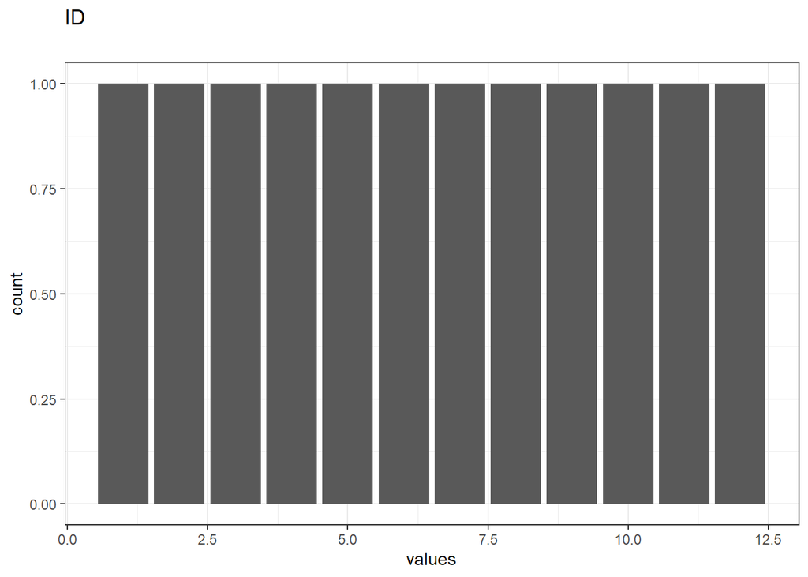

Distribution of values for ID

0 missing values.

#### Summary statistics

| name | data_type | n_missing | complete_rate | min | median | max | mean | sd | hist | label |
| --- | --- | --- | --- | --- | --- | --- | --- | --- | --- | --- |
| ID | numeric | 0 | 1 | 1 | 6.5 | 12 | 6.5 | 3.605551 | ▇▅▅▅▇ | NA |

### Age

#### Distribution

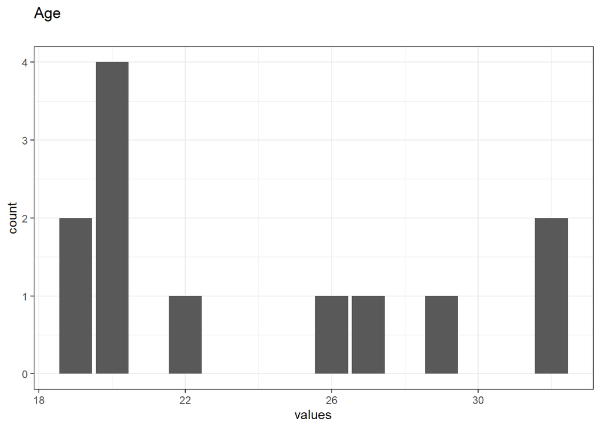

Distribution of values for Age

0 missing values.

#### Summary statistics

| name | data_type | n_missing | complete_rate | min | median | max | mean | sd | hist | label |
| --- | --- | --- | --- | --- | --- | --- | --- | --- | --- | --- |
| Age | numeric | 0 | 1 | 19 | 21 | 32 | 23.83333 | 5.078177 | ▇▁▁▂▂ | NA |

### Height

#### Distribution

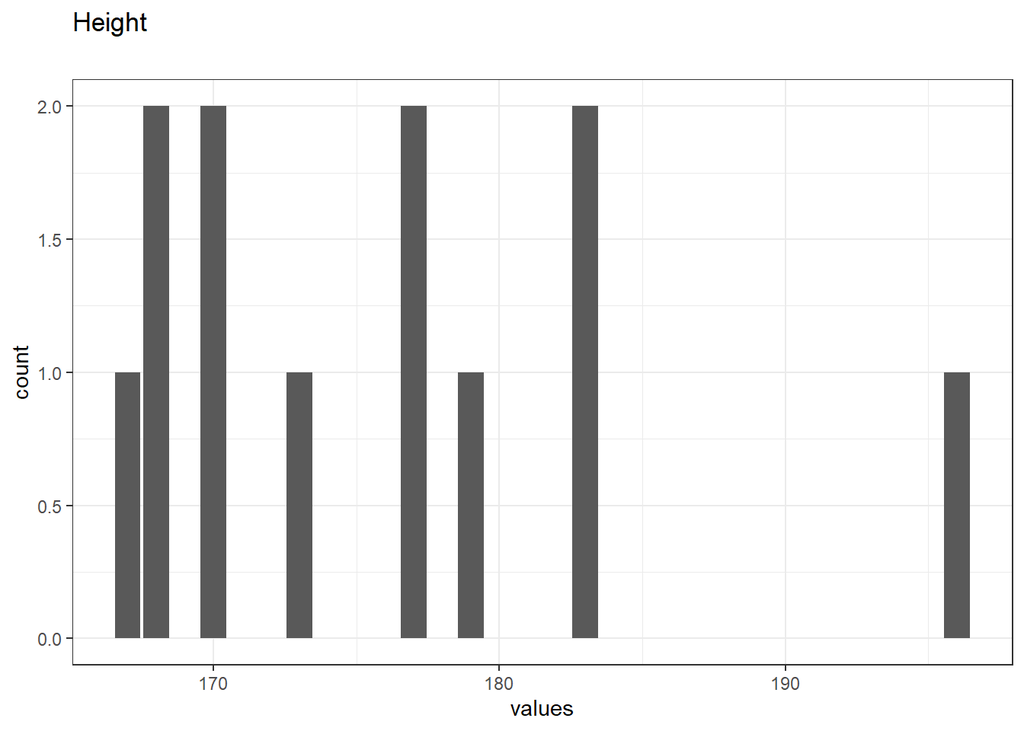

Distribution of values for Height

0 missing values.

#### Summary statistics

| name | data_type | n_missing | complete_rate | min | median | max | mean | sd | hist | label |
| --- | --- | --- | --- | --- | --- | --- | --- | --- | --- | --- |
| Height | numeric | 0 | 1 | 167 | 175 | 196 | 175.9167 | 8.522253 | ▇▅▅▁▂ | NA |

### Weight

#### Distribution

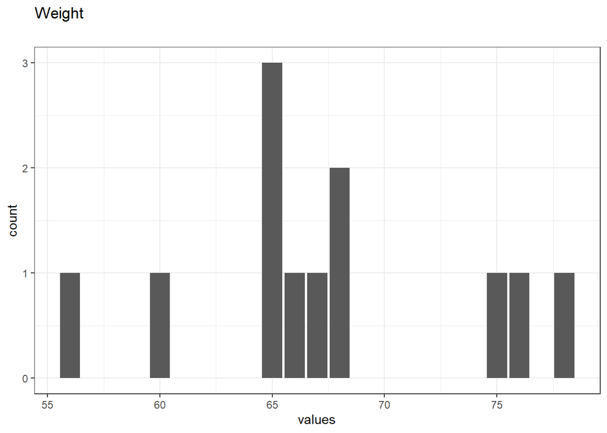

Distribution of values for Weight

0 missing values.

#### Summary statistics

| name | data_type | n_missing | complete_rate | min | median | max | mean | sd | hist | label |
| --- | --- | --- | --- | --- | --- | --- | --- | --- | --- | --- |
| Weight | numeric | 0 | 1 | 56 | 66 | 78 | 67.41667 | 6.388318 | ▂▁▇▁▃ | NA |

### ATT_left

#### Distribution

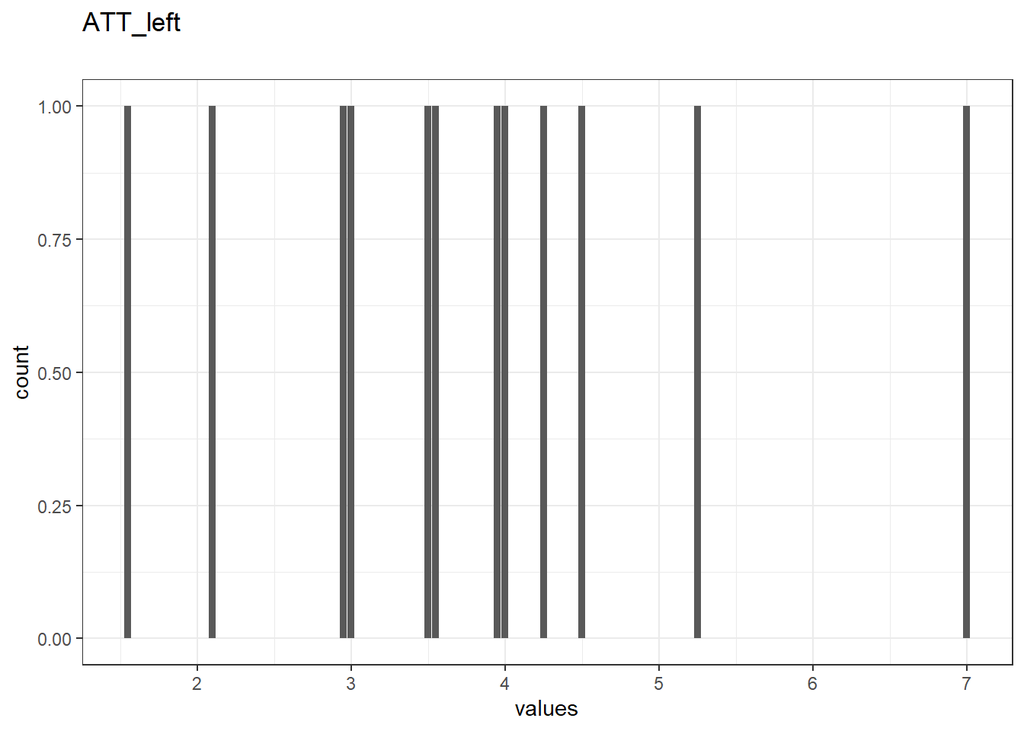

Distribution of values for ATT_left

0 missing values.

#### Summary statistics

| name | data_type | n_missing | complete_rate | min | median | max | mean | sd | hist | label |
| --- | --- | --- | --- | --- | --- | --- | --- | --- | --- | --- |
| ATT_left | numeric | 0 | 1 | 1.6 | 3.8 | 7 | 3.8 | 1.432258 | ▃▇▇▂▂ | NA |

### ATT_right

#### Distribution

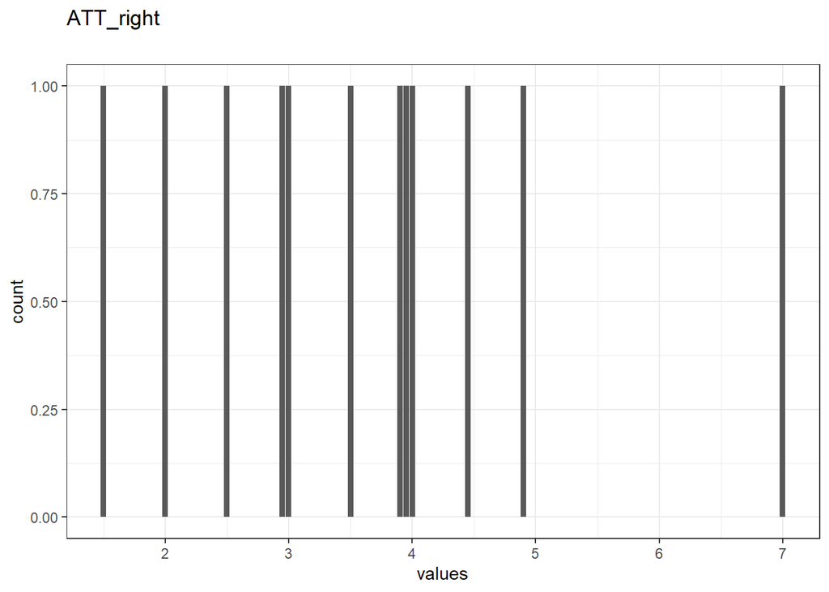

Distribution of values for ATT_right

0 missing values.

#### Summary statistics

| name | data_type | n_missing | complete_rate | min | median | max | mean | sd | hist | label |
| --- | --- | --- | --- | --- | --- | --- | --- | --- | --- | --- |
| ATT_right | numeric | 0 | 1 | 1.5 | 3.7 | 7 | 3.6375 | 1.455417 | ▆▆▇▂▂ | NA |

### Test_duration

#### Distribution

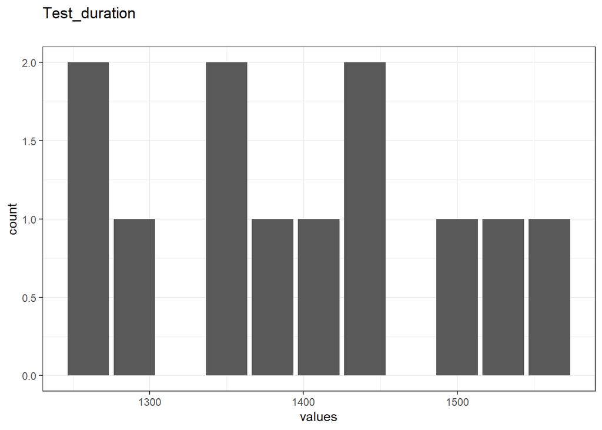

Distribution of values for Test_duration

0 missing values.

#### Summary statistics

| name | data_type | n_missing | complete_rate | min | median | max | mean | sd | hist | label |
| --- | --- | --- | --- | --- | --- | --- | --- | --- | --- | --- |
| Test_duration | numeric | 0 | 1 | 1260 | 1395 | 1560 | 1397.5 | 101.0963 | ▇▇▇▂▅ | NA |

### v_peak

#### Distribution

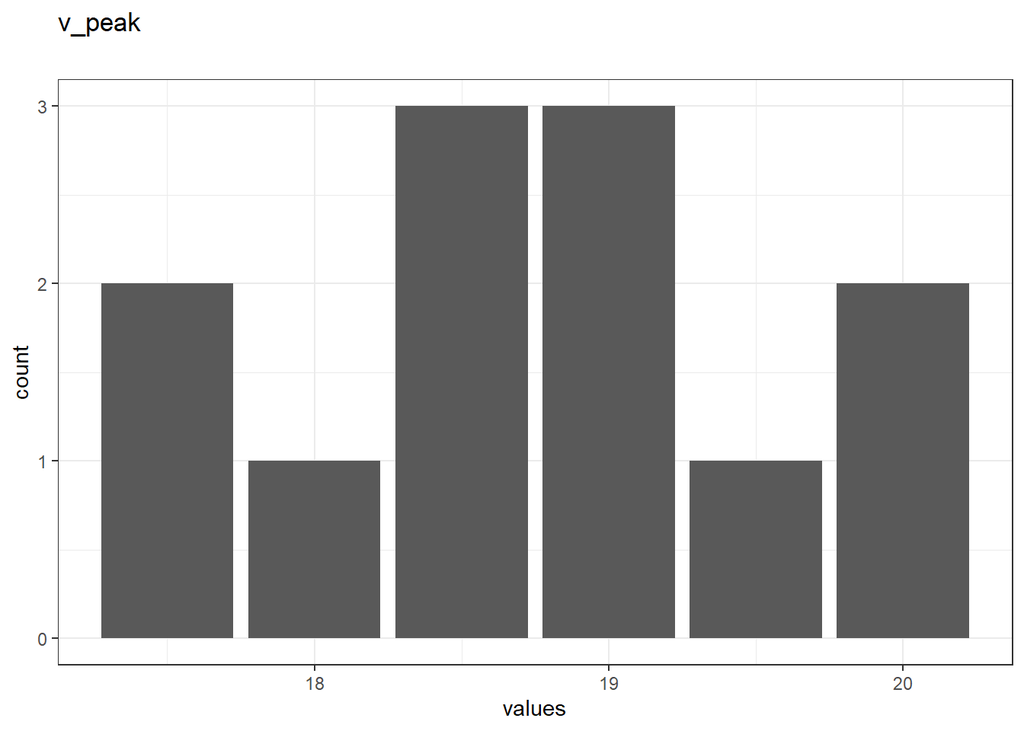

Distribution of values for v_peak

0 missing values.

#### Summary statistics

| name | data_type | n_missing | complete_rate | min | median | max | mean | sd | hist | label |
| --- | --- | --- | --- | --- | --- | --- | --- | --- | --- | --- |
| v_peak | numeric | 0 | 1 | 18 | 19 | 20 | 18.75 | 0.8393721 | ▇▇▇▂▅ | NA |

### MAS

#### Distribution

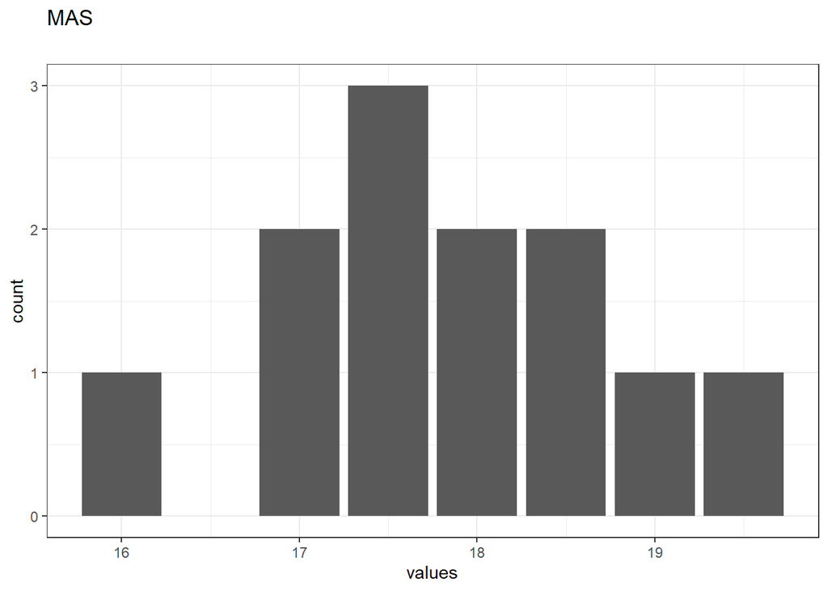

Distribution of values for MAS

0 missing values.

#### Summary statistics

| name | data_type | n_missing | complete_rate | min | median | max | mean | sd | hist | label |
| --- | --- | --- | --- | --- | --- | --- | --- | --- | --- | --- |
| MAS | numeric | 0 | 1 | 16 | 18 | 20 | 17.83333 | 0.9613753 | ▂▃▇▃▃ | NA |

### absVO2max

#### Distribution

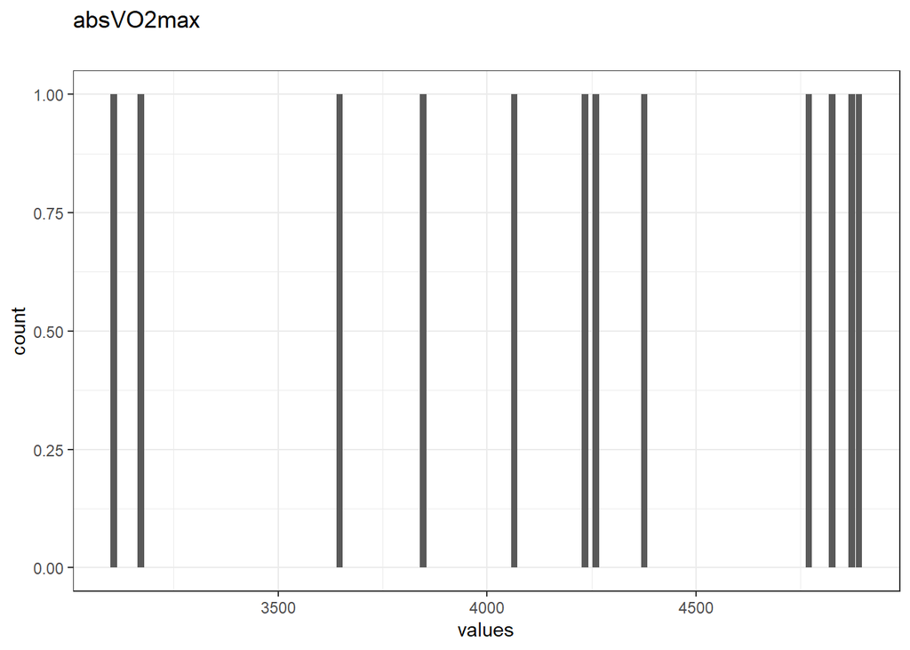

Distribution of values for absVO2max

0 missing values.

#### Summary statistics

| name | data_type | n_missing | complete_rate | min | median | max | mean | sd | hist | label |
| --- | --- | --- | --- | --- | --- | --- | --- | --- | --- | --- |
| absVO2max | numeric | 0 | 1 | 3106 | 4247 | 4890 | 4172.399 | 630.6916 | ▃▂▃▆▇ | NA |

### VO2max

#### Distribution

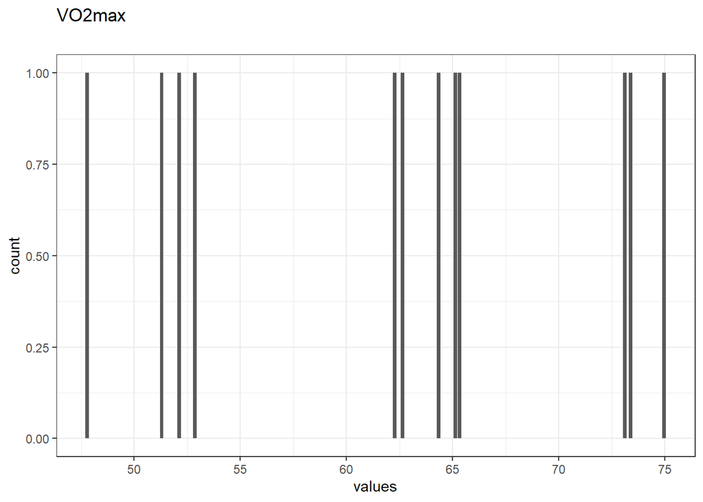

Distribution of values for VO2max

0 missing values.

#### Summary statistics

| name | data_type | n_missing | complete_rate | min | median | max | mean | sd | hist | label |
| --- | --- | --- | --- | --- | --- | --- | --- | --- | --- | --- |
| VO2max | numeric | 0 | 1 | 48 | 63 | 75 | 62.1056 | 9.273661 | ▇▁▃▆▆ | NA |

### GET_time

#### Distribution

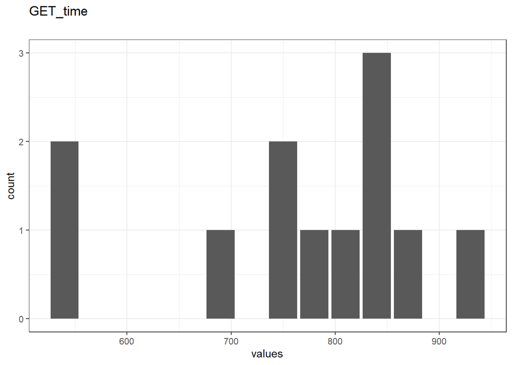

Distribution of values for GET_time

0 missing values.

#### Summary statistics

| name | data_type | n_missing | complete_rate | min | median | max | mean | sd | hist | label |
| --- | --- | --- | --- | --- | --- | --- | --- | --- | --- | --- |
| GET_time | numeric | 0 | 1 | 540 | 795 | 930 | 765 | 122.3631 | ▃▂▃▇▃ | NA |

### GET_speed

#### Distribution

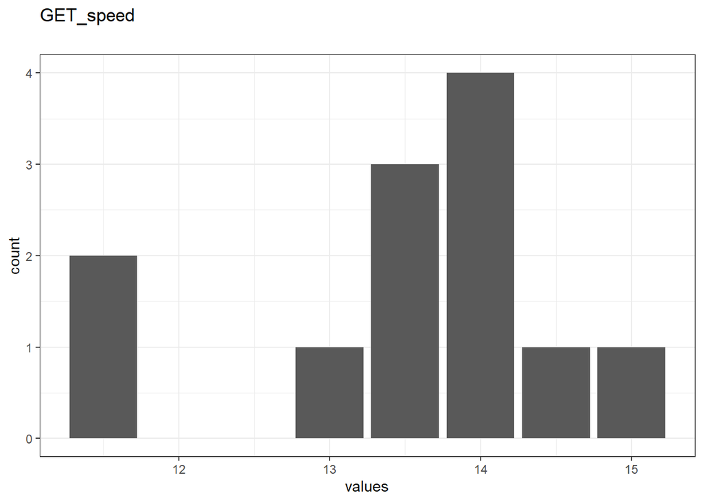

Distribution of values for GET_speed

0 missing values.

#### Summary statistics

| name | data_type | n_missing | complete_rate | min | median | max | mean | sd | hist | label |
| --- | --- | --- | --- | --- | --- | --- | --- | --- | --- | --- |
| GET_speed | numeric | 0 | 1 | 12 | 14 | 15 | 13.5 | 1.066004 | ▃▁▇▇▃ | NA |

### GET_HR

#### Distribution

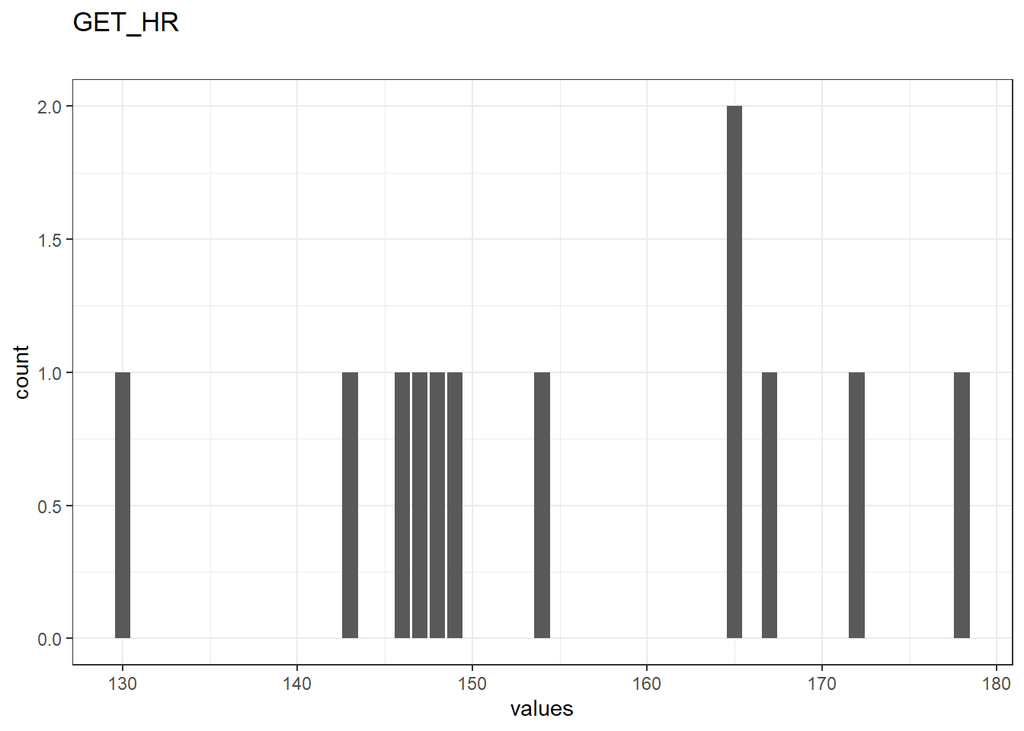

Distribution of values for GET_HR

0 missing values.

#### Summary statistics

| name | data_type | n_missing | complete_rate | min | median | max | mean | sd | hist | label |
| --- | --- | --- | --- | --- | --- | --- | --- | --- | --- | --- |
| GET_HR | numeric | 0 | 1 | 130 | 152 | 178 | 155.3333 | 14.01514 | ▂▇▂▅▃ | NA |

### RCP_time

#### Distribution

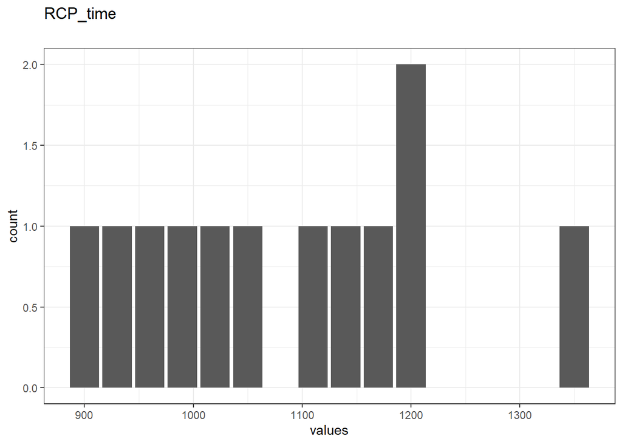

Distribution of values for RCP_time

0 missing values.

#### Summary statistics

| name | data_type | n_missing | complete_rate | min | median | max | mean | sd | hist | label |
| --- | --- | --- | --- | --- | --- | --- | --- | --- | --- | --- |
| RCP_time | numeric | 0 | 1 | 900 | 1080 | 1350 | 1085 | 133.4507 | ▇▃▆▃▂ | NA |

### RCP_speed

#### Distribution

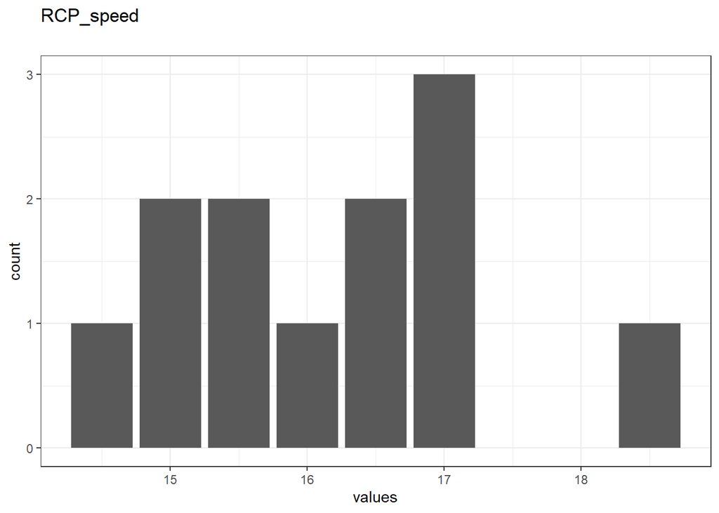

Distribution of values for RCP_speed

0 missing values.

#### Summary statistics

| name | data_type | n_missing | complete_rate | min | median | max | mean | sd | hist | label |
| --- | --- | --- | --- | --- | --- | --- | --- | --- | --- | --- |
| RCP_speed | numeric | 0 | 1 | 14 | 16 | 18 | 16.16667 | 1.134848 | ▇▇▅▇▂ | NA |

### RCP_HR

#### Distribution

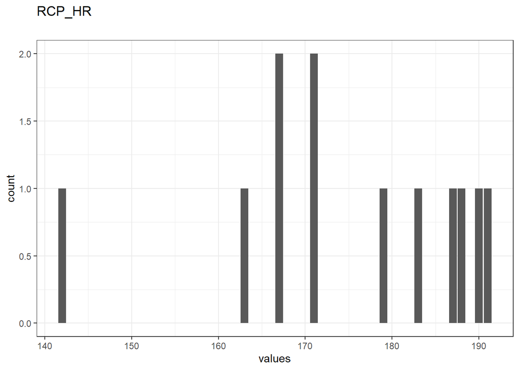

Distribution of values for RCP_HR

0 missing values.

#### Summary statistics

| name | data_type | n_missing | complete_rate | min | median | max | mean | sd | hist | label |
| --- | --- | --- | --- | --- | --- | --- | --- | --- | --- | --- |
| RCP_HR | numeric | 0 | 1 | 142 | 175 | 191 | 174.9167 | 14.3556 | ▂▁▇▂▇ | NA |

### BP1_time

#### Distribution

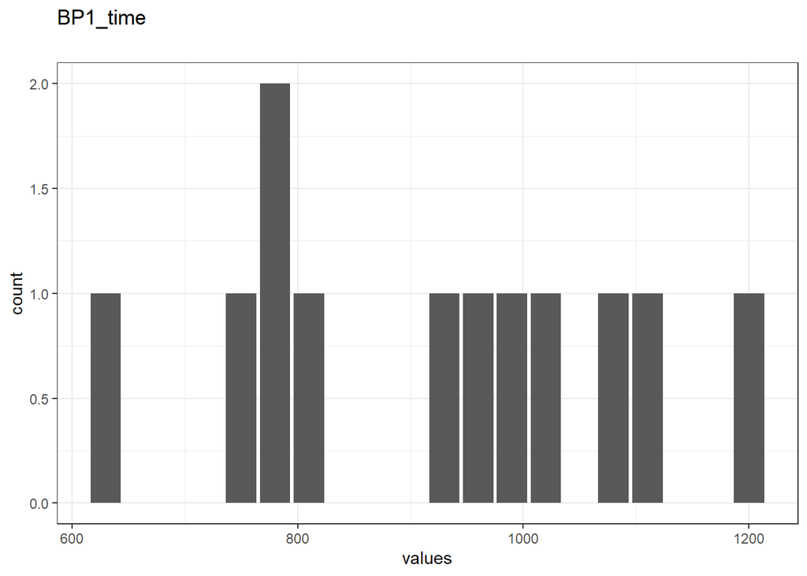

Distribution of values for BP1_time

0 missing values.

#### Summary statistics

| name | data_type | n_missing | complete_rate | min | median | max | mean | sd | hist | label |
| --- | --- | --- | --- | --- | --- | --- | --- | --- | --- | --- |
| BP1_time | numeric | 0 | 1 | 630 | 945 | 1200 | 920 | 170.8269 | ▂▇▃▆▃ | NA |

### BP1_speed

#### Distribution

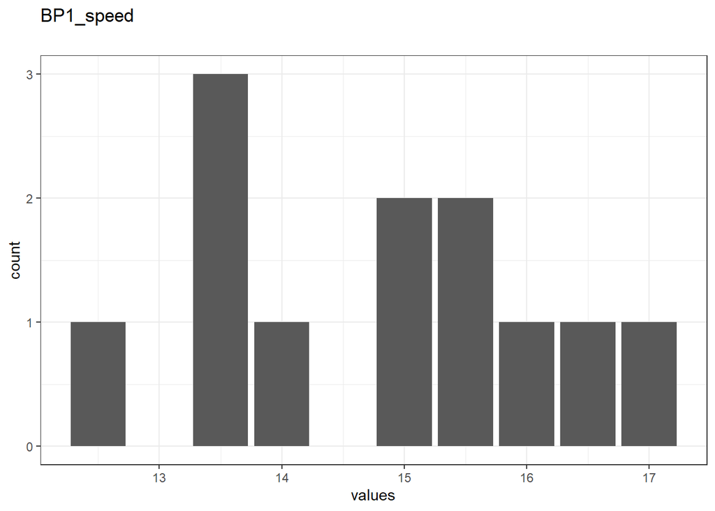

Distribution of values for BP1_speed

0 missing values.

#### Summary statistics

| name | data_type | n_missing | complete_rate | min | median | max | mean | sd | hist | label |
| --- | --- | --- | --- | --- | --- | --- | --- | --- | --- | --- |
| BP1_speed | numeric | 0 | 1 | 12 | 15 | 17 | 14.79167 | 1.389217 | ▂▇▃▆▃ | NA |

### BP1_HR

#### Distribution

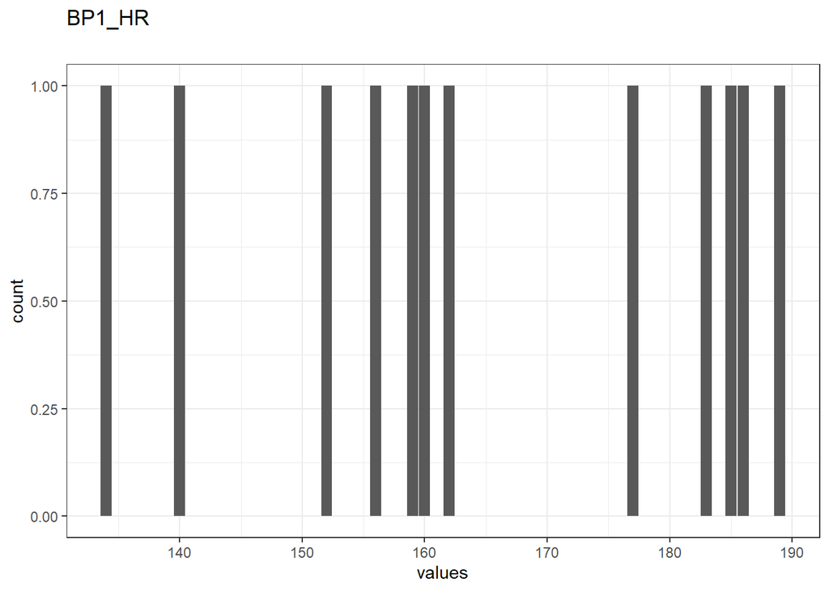

Distribution of values for BP1_HR

0 missing values.

#### Summary statistics

| name | data_type | n_missing | complete_rate | min | median | max | mean | sd | hist | label |
| --- | --- | --- | --- | --- | --- | --- | --- | --- | --- | --- |
| BP1_HR | numeric | 0 | 1 | 134 | 161 | 189 | 165.25 | 18.56255 | ▃▃▆▂▇ | NA |

### BP2_time

#### Distribution

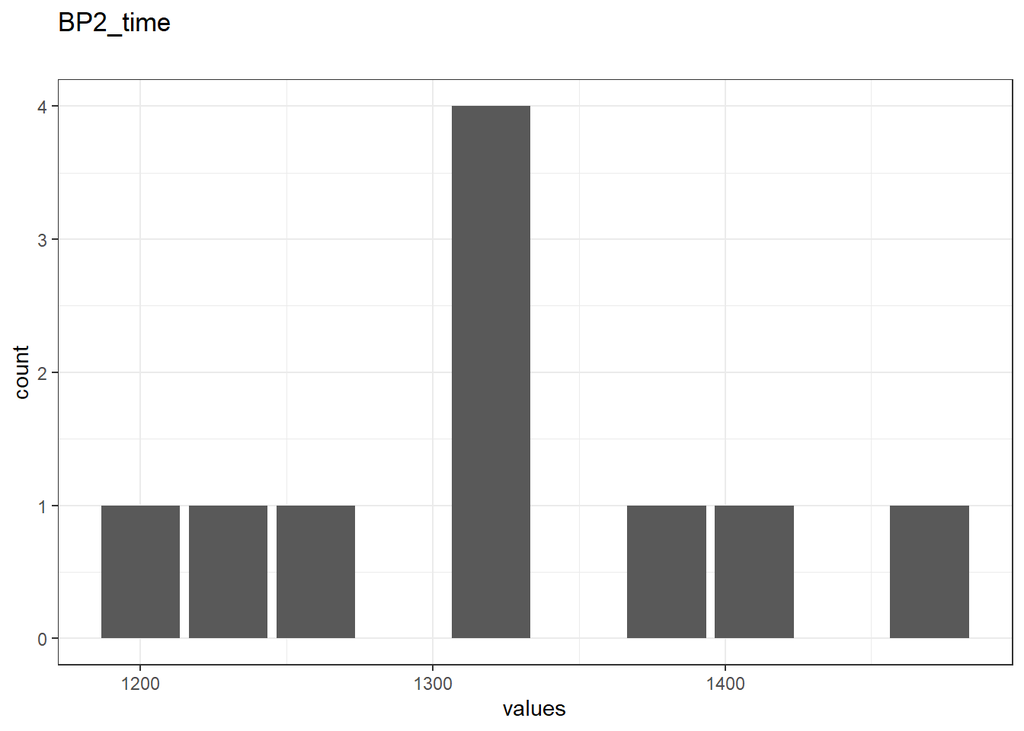

Distribution of values for BP2_time

2 missing values.

#### Summary statistics

| name | data_type | n_missing | complete_rate | min | median | max | mean | sd | hist | label |
| --- | --- | --- | --- | --- | --- | --- | --- | --- | --- | --- |
| BP2_time | numeric | 2 | 0.8333333 | 1200 | 1320 | 1470 | 1323 | 81.79242 | ▃▂▇▃▂ | NA |

### BP2_speed

#### Distribution

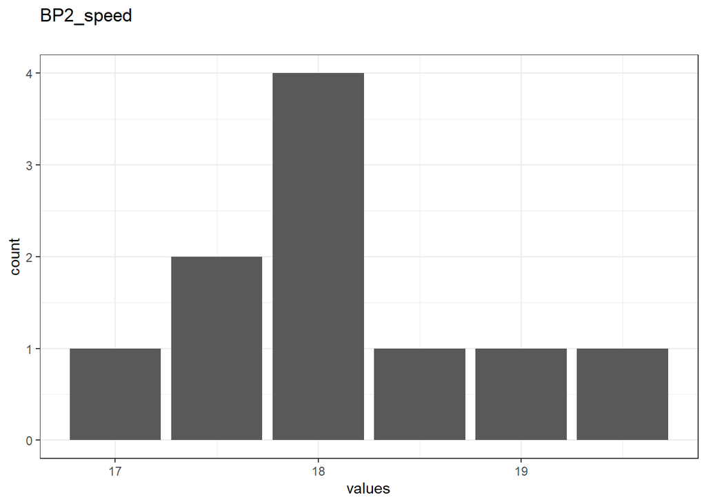

Distribution of values for BP2_speed

2 missing values.

#### Summary statistics

| name | data_type | n_missing | complete_rate | min | median | max | mean | sd | hist | label |
| --- | --- | --- | --- | --- | --- | --- | --- | --- | --- | --- |
| BP2_speed | numeric | 2 | 0.8333333 | 17 | 18 | 20 | 18.1 | 0.7378648 | ▆▇▂▂▂ | NA |

### BP2_HR

#### Distribution

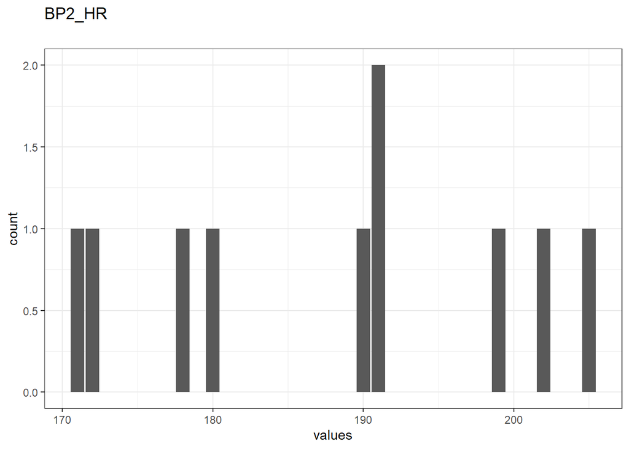

Distribution of values for BP2_HR

2 missing values.

#### Summary statistics

| name | data_type | n_missing | complete_rate | min | median | max | mean | sd | hist | label |
| --- | --- | --- | --- | --- | --- | --- | --- | --- | --- | --- |
| BP2_HR | numeric | 2 | 0.8333333 | 171 | 190 | 205 | 187.9 | 12.18788 | ▅▅▇▁▇ | NA |

## Missingness report

| description | BP2_time | BP2_speed | BP2_HR | var_miss | n_miss |
| --- | --- | --- | --- | --- | --- |
| Missing values in 0 variables | 1 | 1 | 1 | 0 | 10 |
| Missing values per variable | 2 | 2 | 2 | 6 | 6 |
| Missing values in 3 variables | 0 | 0 | 0 | 3 | 2 |